# DATA252: Moving Beyond Linearity

Kitada Smalley

## Learning Objectives

In this lesson students will learn how to…

- Fit non-linear models (polynomial, gam, and loess)
- Choose the appropriate amount of curvature using p-values
- Choose hyper parameters via testing and training

## 0. Import the Data

During the COVID-19 Pandemic several researchers published work on estimating/forecasting the number of cases. Due to the non-linear nature of these data many of the researchers chose to fit polynomial regression models.

Read more here:

- Revisiting the standard for modeling the spread of infectious diseases https://www.nature.com/articles/s41598-022-10185-0
- On Modeling of COVID-19 for the Indian Subcontinent using Polynomial and Supervised Learning Regression https://www.medrxiv.org/content/10.1101/2020.10.14.20212563v1.full
- Regression Polynomial Analysis of the COVID-19 Epidemics: An Alternative Infection Modeling https://europepmc.org/article/ppr/ppr244391
- COVID-19 Epidemic Analysis Using Linear and Polynomial Regression Approach https://link.springer.com/chapter/10.1007/978-981-15-7317-0_13

### Example 1: Covid-19 in India

```r
library(tidyverse)

covid<-read.csv("https://raw.githubusercontent.com/kitadasmalley/DATA252/main/Data/complete.csv")
str(covid)
```

```
## 'data.frame':    4692 obs. of  10 variables:
##  $ Date                     : chr  "2020-01-30" "2020-01-31" "2020-02-01" "2020-02-02" ...
##  $ Name.of.State...UT       : chr  "Kerala" "Kerala" "Kerala" "Kerala" ...
##  $ Latitude                 : num  10.9 10.9 10.9 10.9 10.9 ...
##  $ Longitude                : num  76.3 76.3 76.3 76.3 76.3 ...
##  $ Total.Confirmed.cases    : num  1 1 2 3 3 3 3 3 3 3 ...
##  $ Death                    : chr  "0" "0" "0" "0" ...
##  $ Cured.Discharged.Migrated: num  0 0 0 0 0 0 0 0 0 0 ...
##  $ New.cases                : int  0 0 1 1 0 0 0 0 0 0 ...
##  $ New.deaths               : int  0 0 0 0 0 0 0 0 0 0 ...
##  $ New.recovered            : int  0 0 0 0 0 0 0 0 0 0 ...
```

We are going to need to wrangle it:

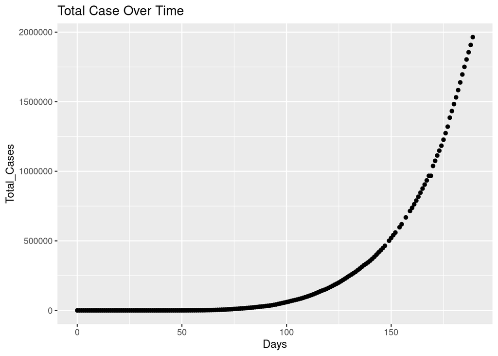

```r
library(magrittr)

## NEEDS TO BE A DATE OBJECT
covid$Date<-as.Date(covid$Date)

## CREATE A VECTOR OF UNIQUE DATES
dateRange<-unique(covid$Date)

## INITIALIZE EMPTY VECTOR FOR CASES
cases<-c()

for(i in 1:length(dateRange)){

## CALCULATE NUMBER OF NEW CASES ACROSS ALL STATES
covidThisDate<-covid%>%
  filter(Date==dateRange[i])%$%
  sum(New.cases)+1

cases<-c(cases, covidThisDate)
}

## Create a new data frame
newCaseDate<-data.frame(Date=dateRange,
                        Daily_Cases=cases,
                        ## CUMULATIVE SUM
                        Total_Cases=cumsum(cases)
                        )%>%
  mutate(Start=as.Date("2020-01-30"))%>%
  ## NUMBER OF DAYS SINCE START 1/30/2020
  mutate(Days=as.numeric(Date-Start))


## Plot for Total Cases
ggplot(newCaseDate, aes(x=Days, y=Total_Cases))+
  geom_point()+
  ggtitle("Total Case Over Time")
```

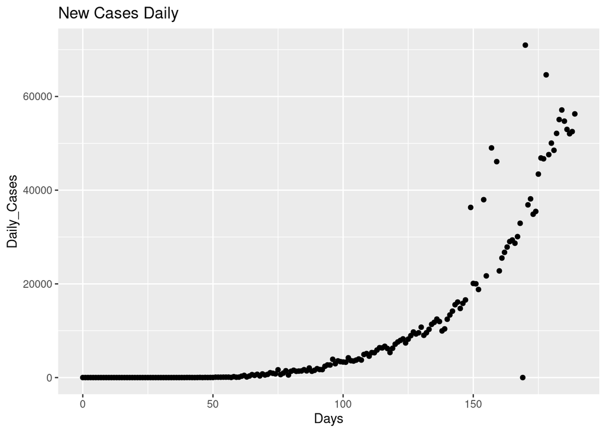

```r
## Plot for New Cases in a day
ggplot(newCaseDate, aes(x=Days, y=Daily_Cases))+
  geom_point()+
  ggtitle("New Cases Daily")
```

#### Question:

- What it be appropriate to fit a linear model to these data? Why or why not?

## 1. Polynomial Regression

Polynomial regression is used to fit a curved relationship between the feature $X$ and the outcome $Y$.

$$Y=\beta_0+\beta_1 X+\beta_2 X^2+\beta_3
X^3+\cdot+\beta_p X^p+\varepsilon$$

Polynomial regression has been applied in:

- Rate of growth of tissues.
- Progression of the epidemics related to disease.
- Distribution phenomenon of the isotopes of carbon

### How many polynomial terms should we add?

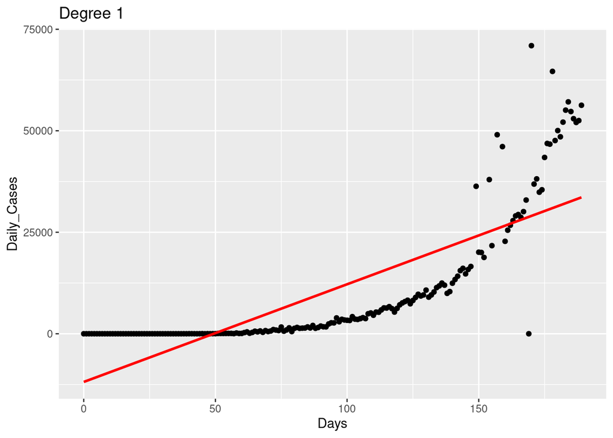

```r
## DEGREE 1: Linear Model
model_1 <- lm(Daily_Cases ~ poly(Days,1), data = newCaseDate)

ggplot(newCaseDate, aes(x=Days, y=Daily_Cases))+
  geom_point()+
  geom_line(aes(y=model_1$fitted.values), color="red", size=1)+
  ggtitle("Degree 1")
```

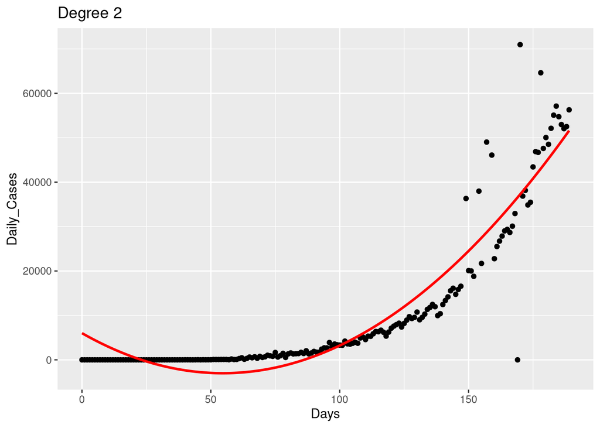

```r
## Degree 2: Quadratic
model_2 <- lm(Daily_Cases ~ poly(Days,2), data = newCaseDate)

ggplot(newCaseDate, aes(x=Days, y=Daily_Cases))+
  geom_point()+
  geom_line(aes(y=model_2$fitted.values), color="red", size=1)+
  ggtitle("Degree 2")
```

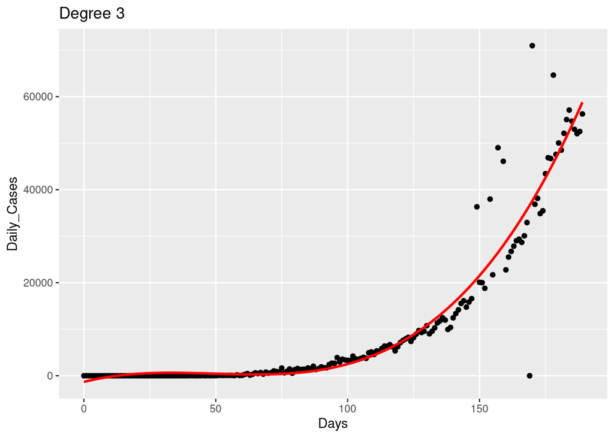

```r
## Degree 3: Cubic
model_3 <- lm(Daily_Cases ~ poly(Days,3), data = newCaseDate)

ggplot(newCaseDate, aes(x=Days, y=Daily_Cases))+
  geom_point()+
  geom_line(aes(y=model_3$fitted.values), color="red", size=1)+
  ggtitle("Degree 3")
```

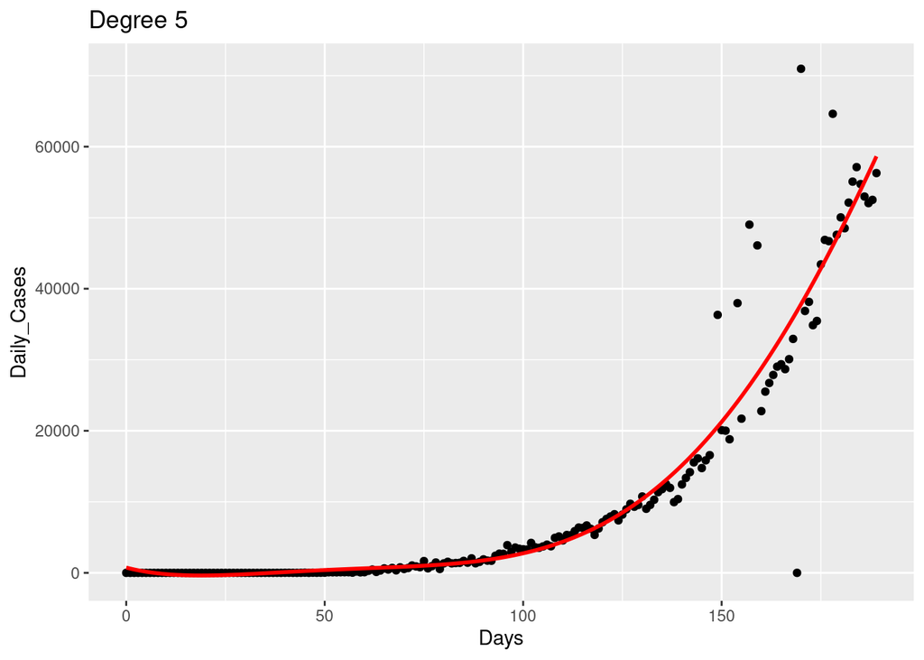

```r
## Degree 5
model_5 <- lm(Daily_Cases ~ poly(Days,5), data = newCaseDate)

ggplot(newCaseDate, aes(x=Days, y=Daily_Cases))+
  geom_point()+
  geom_line(aes(y=model_5$fitted.values), color="red", size=1)+
  ggtitle("Degree 5")
```

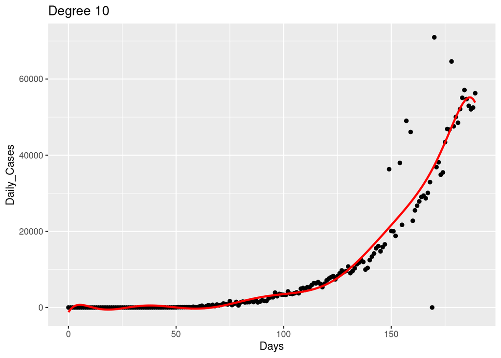

```r
## Degree 10
model_10 <- lm(Daily_Cases ~ poly(Days,10), data = newCaseDate)

ggplot(newCaseDate, aes(x=Days, y=Daily_Cases))+
  geom_point()+
  geom_line(aes(y=model_10$fitted.values), color="red", size=1)+
  ggtitle("Degree 10")
```

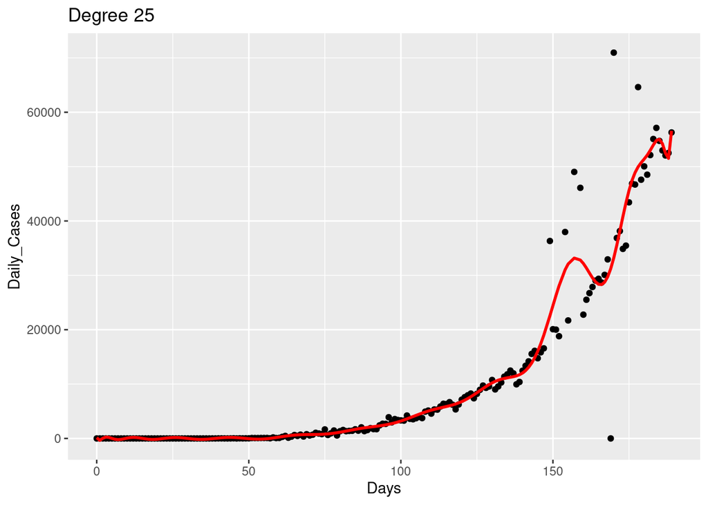

```r
## Degree 25
model_25 <- lm(Daily_Cases ~ poly(Days,25), data = newCaseDate)

ggplot(newCaseDate, aes(x=Days, y=Daily_Cases))+
  geom_point()+
  geom_line(aes(y=model_25$fitted.values), color="red", size=1)+
  ggtitle("Degree 25")
```

### What Would A Statistician Do?

Look for significant variables.

```r
model <- lm(Daily_Cases ~ poly(Days,6), data = newCaseDate)

summary(model)
```

[output not shown]

#### Question:

- Which is the last polynomial term that is significant at an $\alpha=0.05$ level?

### Only Significant Terms!

```r
final.model <- lm(Daily_Cases ~ poly(Days,3), data = newCaseDate)

summary(final.model)
```

```
##
## Call:
## lm(formula = Daily_Cases ~ poly(Days, 3), data = newCaseDate)
##
## Residuals:
##    Min     1Q Median     3Q    Max
## -36644   -636   -142    613  33371
##
## Coefficients:
##                Estimate Std. Error t value Pr(>|t|)
## (Intercept)     10561.6      369.8  28.562  < 2e-16 ***
## poly(Days, 3)1 179540.2     5043.1  35.601  < 2e-16 ***
## poly(Days, 3)2 112060.6     5043.1  22.221  < 2e-16 ***
## poly(Days, 3)3  39258.2     5043.1   7.785  5.1e-13 ***
## ---
## Signif. codes:  0 '***' 0.001 '**' 0.01 '*' 0.05 '.' 0.1 ' ' 1
##
## Residual standard error: 5043 on 182 degrees of freedom
## Multiple R-squared:  0.9092, Adjusted R-squared:  0.9077
## F-statistic: 607.3 on 3 and 182 DF,  p-value: < 2.2e-16
```

#### Question:

- What the model using the coefficients estimated in R.

### What Would Be Done in the Machine Learning Paradigm?

Training and Testing!

We should split the data into the training set to build/train a model and then predict values using the testing set. Since we actually know the true observations we can asses how much error there was. In reality, we aren’t about to know how much error there was in predictions until the event we were trying to forecast for is in the past.

```r
trainInd<-sample(1:186, 130)
trainDat<-newCaseDate[trainInd, ]
testDat<-newCaseDate[-trainInd, ]
```

#### Grid Search

In order to find the amount of curvature we would like in the model, we will perform a grid search. This means we will fit our model with the training set and a given amount of curvature (degree of polynomial). We then use this model to predicting the testing set and assess the resulting error. This process is repeated over and over until we have moved through the whole grid.

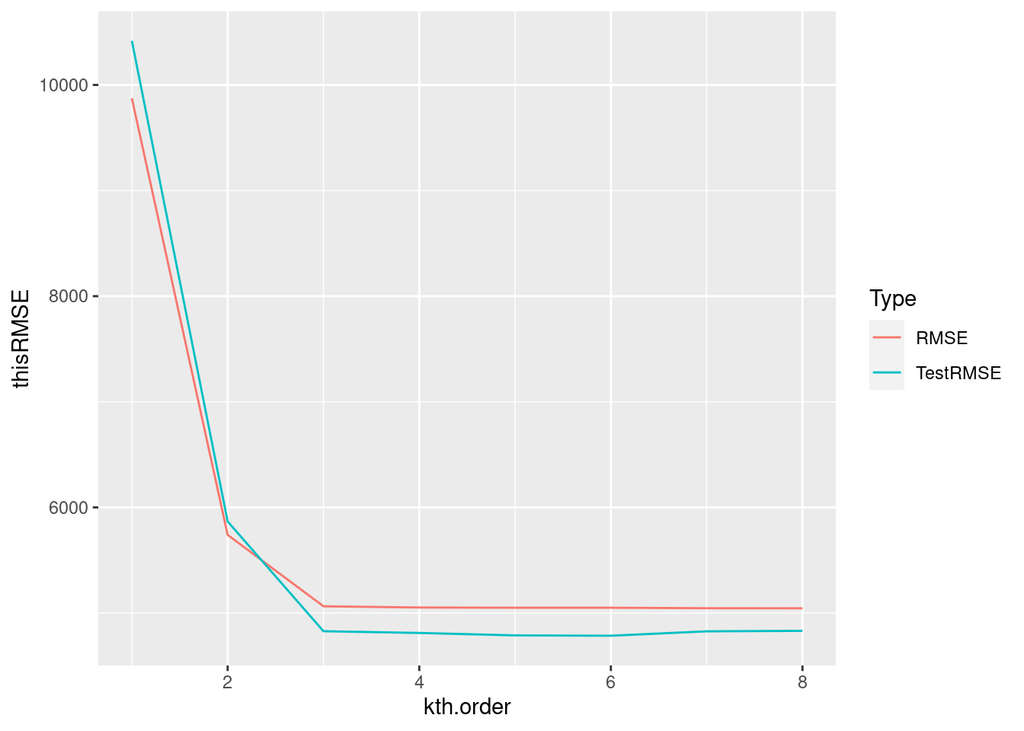

```r
# setup
RMSE <- data.frame('kth.order' = NA, 'RMSE' = NA, 'TestRMSE'=NA) # empty data frame to store RMSE
vals <- list('Days' <- seq(min(newCaseDate$Days), max(newCaseDate$Days), by = 0.01)) # set up vector used for prediction

## THIS IS CALLED A GRID SEARCH
#k-th order
k <- 1:8

# run  loop
for (i in 1:length(k)){
  # build models
  model <- lm(Daily_Cases ~ poly(Days,k[i]), data = trainDat)

  # calculate RSME and store it for further usage
  RMSE[i,1] <- k[i] # store k-th order
  RMSE[i,2] <- sqrt(sum((fitted(model)-trainDat$Daily_Cases)^2)/length(trainDat$Daily_Cases)) # calculate RSME

  predTest<-predict(model, testDat)

  RMSE[i, 3]<-sqrt(sum((predTest-testDat$Daily_Cases)^2)/length(testDat$Daily_Cases)) # calculate RSME

}

## USE GATHER TO CREATE A NEW COL TO DIFFERENTIATE THE TYPE OF RMSE
RMSE%>%
  gather(key="Type", value="thisRMSE", -c(kth.order))%>%
  ggplot(aes(x=kth.order, y=thisRMSE, color=Type))+
  geom_line()
```

## 2. Cross-Validation

### Example 2: Synthetic Data

Generate Synthetic Data

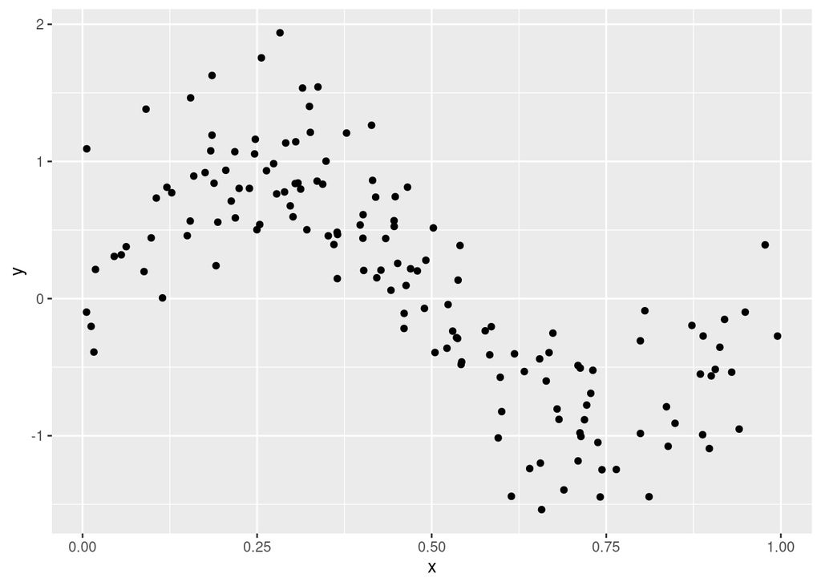

```r
#### CITATION: https://www.geo.fu-berlin.de/en/v/soga/Basics-of-statistics/Linear-Regression/Polynomial-Regression/Polynomial-Regression---An-example/index.html
##### Data generating function #####
set.seed(400) # set seed for reproducibility
n <- 150
x <- runif(n, 0, 1)
y <- sin(2*pi*x) + rnorm(n, 0, 0.35)
poly.data <- data.frame('x' = x, 'y' = y)

library(tidyverse)

ggplot(poly.data , aes(x, y))+
  geom_point()
```

### k-fold CV

It is common to use $k=5$ folds

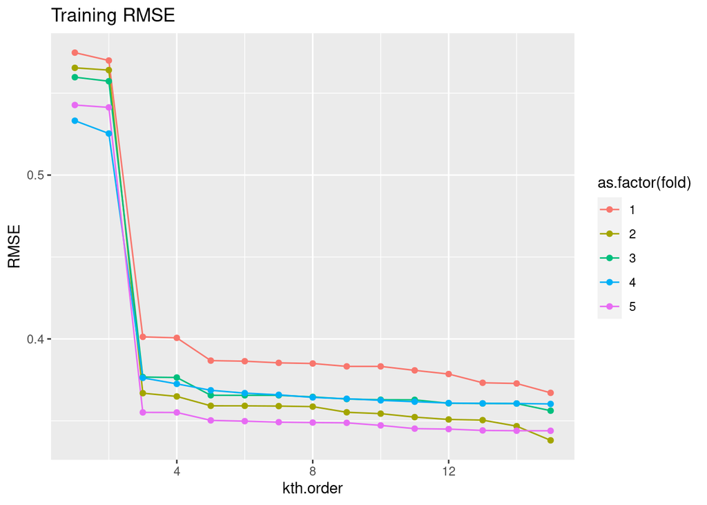

```r
### HOLD MANY FOLDS
kf<-5

### RANDOM SPLIT INTO K FOLDS
### RANDOM INDEXES
ind<-sample(1:150)

### CREATE DF
folds<-data.frame(ind,
                  fold=rep(1:kf, 150/kf))

### ADD ON COLUMNS TO ORIGINAL DAT
foldPoly<-poly.data[ind,]%>%
  cbind(folds)

### INITIALIZE RMSE DATAFRAME TO HOLD OUTPUT
RMSE <- data.frame('fold' = NA, 'kth.order' = NA, 'RMSE' = NA, 'TestRMSE'=NA) # empty data frame to store RMSE

### LOOP FOR CROSS-VALIDATION
for(i in 1:kf){
  trainDat<-foldPoly%>%
    filter(fold!=i)

  testDat<-foldPoly%>%
    filter(fold==i)

  ### INNER LOOP FOR POLY DEGREE
  k <- 1:15 #k-th order

  for (j in 1:length(k)){
    row<-length(k)*(i-1)+j

    # build models
    model <- lm(y ~ poly(x,k[j]), data = trainDat)

    # calculate RSME and store it for further usage
    RMSE[row,1] <-i
    RMSE[row,2] <- k[j] # store k-th order
    RMSE[row,3] <- sqrt(sum((fitted(model)-trainDat$y)^2)/length(trainDat$y)) # calculate RSME

    predTest<-predict(model, testDat)

    RMSE[row, 4]<-sqrt(sum((predTest-testDat$y)^2)/length(testDat$y)) # calculate RSME

  }
}


ggplot(RMSE, aes(x=kth.order, y=RMSE, color=as.factor(fold)))+
  geom_line()+
  geom_point()+
  ggtitle("Training RMSE")
```

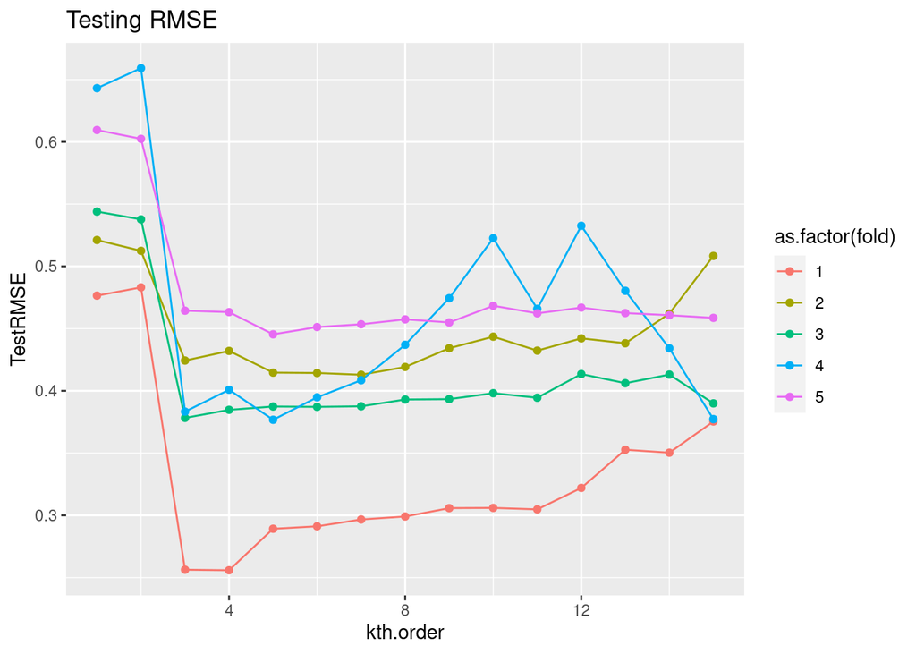

```r
ggplot(RMSE, aes(x=kth.order, y=TestRMSE, color=as.factor(fold)))+
  geom_line()+
  geom_point()+
  ggtitle("Testing RMSE")
```

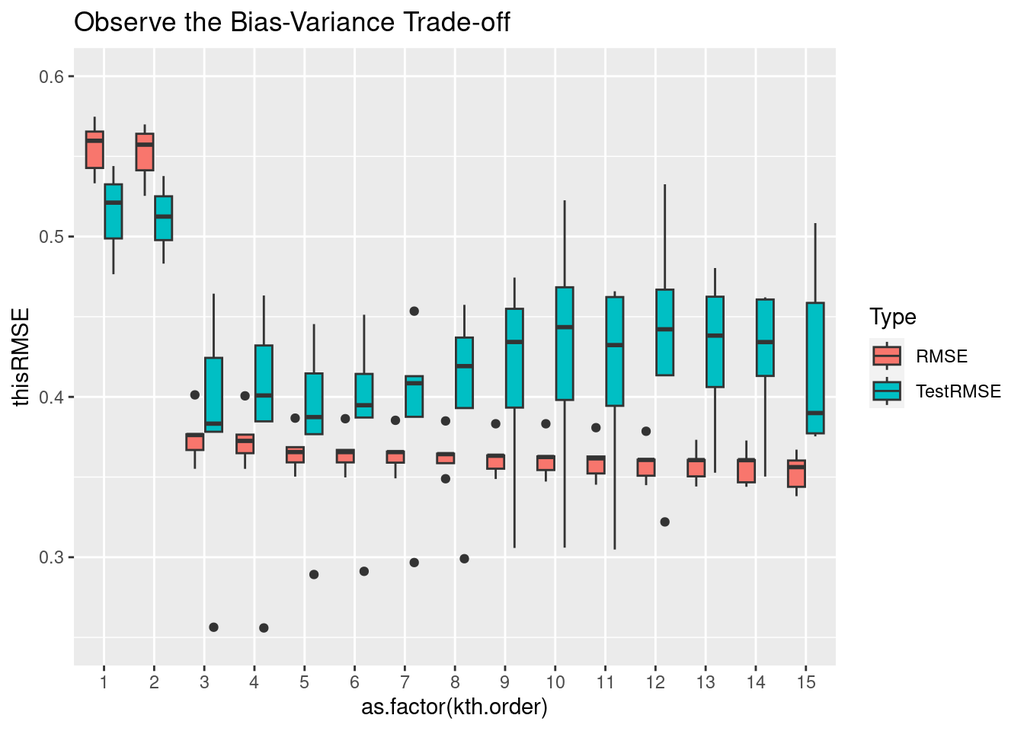

```r
### TIDY GRAPHICS TO PLOT TOGETHER
tidyRMSE<-RMSE%>%
  gather(key="Type", value="thisRMSE", -c(fold, kth.order))

ggplot(tidyRMSE, aes(x=as.factor(kth.order), y=thisRMSE, fill=Type))+
  geom_boxplot()+
  ylim(c(.25, .6))+
  ggtitle("Observe the Bias-Variance Trade-off")
```

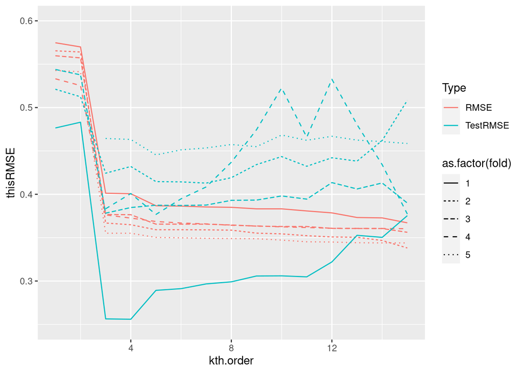

```r
ggplot(tidyRMSE, aes(x=kth.order, y=thisRMSE,
                     color=Type, lty=as.factor(fold)))+
  geom_line()+
  ylim(c(.25, .6))
```

### Aggregate the folds

```r
### AGGREGATE CROSS_VALIDATION
cvRMSE<-RMSE%>%
  group_by(kth.order)%>%
  summarise(avgTrainMSE=mean(RMSE),
            avgTestMSE=mean(TestRMSE),
            sdTrain=sd(RMSE),
            sdTest=sd(TestRMSE))

cvRMSE
```

```
## # A tibble: 15 × 5
##    kth.order avgTrainMSE avgTestMSE sdTrain sdTest
##        <int>       <dbl>      <dbl>   <dbl>  <dbl>
##  1         1       0.555      0.559  0.0169 0.0673
##  2         2       0.552      0.559  0.0182 0.0712
##  3         3       0.375      0.381  0.0170 0.0781
##  4         4       0.374      0.387  0.0170 0.0794
##  5         5       0.366      0.383  0.0135 0.0586
##  6         6       0.366      0.388  0.0135 0.0594
##  7         7       0.365      0.392  0.0133 0.0583
##  8         8       0.364      0.401  0.0132 0.0618
##  9         9       0.363      0.413  0.0130 0.0668
## 10        10       0.362      0.428  0.0135 0.0816
## 11        11       0.361      0.412  0.0134 0.0664
## 12        12       0.359      0.435  0.0128 0.0772
## 13        13       0.358      0.428  0.0111 0.0505
## 14        14       0.357      0.424  0.0117 0.0460
## 15        15       0.353      0.422  0.0119 0.0592
```

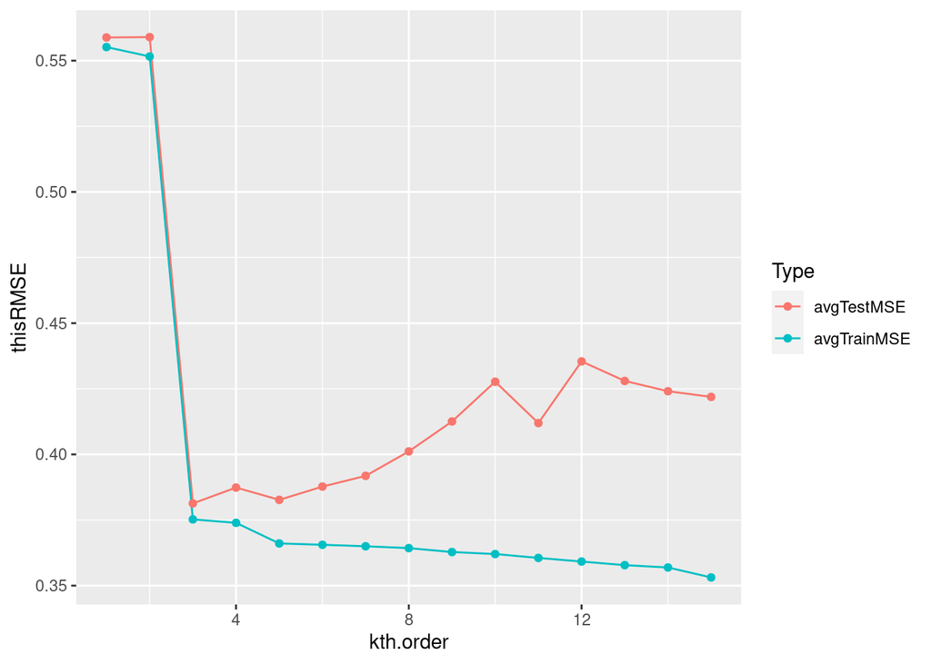

```r
cvRMSE%>%
  gather(key="Type", value=thisRMSE, -c(kth.order))%>%
  filter(Type %in% c("avgTrainMSE", "avgTestMSE"))%>%
  ggplot(aes(x=kth.order, y=thisRMSE, color=Type))+
  geom_line()+
  geom_point()
```

```r
### WHICH MINIMIZES
which.min(cvRMSE$avgTestMSE)
```

```
## [1] 3
```

```r
cvRMSE$avgTestMSE[which.min(cvRMSE$avgTestMSE)]
```

```
## [1] 0.3813249
```

#### QUESTION:

- Repeat with 10 folds. What observations do you make?

```r
## THIS SPACE IS FOR YOUR CODE ##
```

## 2. GAM

Generalized additive models provide a flexible modeling technique that can account for non-linear relationships. This type of modeling falls under the generalized linear model framework and linked with smoothing (spline) functions. The big idea is that sections of the data (separated by knots) can be split up and modeled using a non-linear method. These sections and then combined and smoothed.

### Ex 1: COVID-19

The `s()` function tells are to automatically find the “best” knots for the smoothing spline.

```r
#install.packages("mgcv")
library(mgcv)

mod_gam<-gam(Daily_Cases ~ s(Days), data = newCaseDate)
summary(mod_gam)
```

```
##
## Family: gaussian
## Link function: identity
##
## Formula:
## Daily_Cases ~ s(Days)
##
## Parametric coefficients:
##             Estimate Std. Error t value Pr(>|t|)
## (Intercept)    10562        370   28.55   <2e-16 ***
## ---
## Signif. codes:  0 '***' 0.001 '**' 0.01 '*' 0.05 '.' 0.1 ' ' 1
##
## Approximate significance of smooth terms:
##           edf Ref.df     F p-value
## s(Days) 4.823  5.898 306.7  <2e-16 ***
## ---
## Signif. codes:  0 '***' 0.001 '**' 0.01 '*' 0.05 '.' 0.1 ' ' 1
##
## R-sq.(adj) =  0.908   Deviance explained =   91%
## GCV = 2.6286e+07  Scale est. = 2.5463e+07  n = 186
```

Looking at the output you will see `edf` which stands for effective degrees of freedom. We can think of this as “the more wiggly the line is, the higher this number should be”. An `edf` of one would mean that the linear is linear. P-values from this table should be considered approximate.

Now, let’s make a graph to compare the GAM model with the polynomial model.

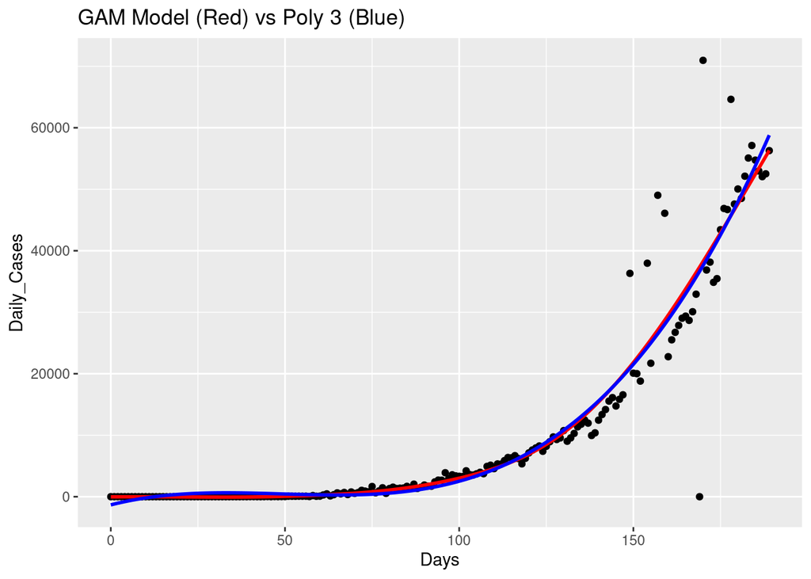

```r
ggplot(newCaseDate, aes(x=Days, y=Daily_Cases))+
  geom_point()+
  geom_line(aes(y=mod_gam$fitted.values), color="red", size=1)+
  geom_line(aes(y=model_3$fitted.values), color="blue", size=1)+
  ggtitle("GAM Model (Red) vs Poly 3 (Blue)")
```

### Ex 2: Synthetic Data

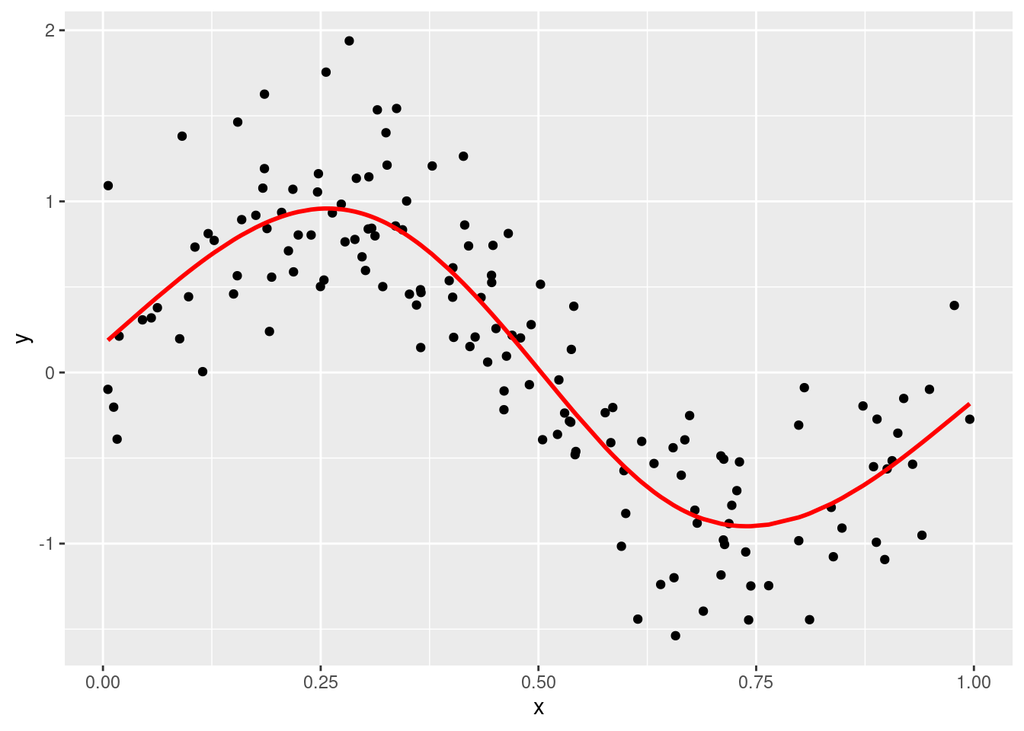

```r
mod_gam2<-gam(y ~ s(x), data = poly.data)

ggplot(poly.data, aes(x=x, y=y))+
  geom_point()+
  geom_line(aes(y=mod_gam2$fitted.values), color="red", size=1)
```

## 3. LOESS

LOESS (locally estimated scatterplot smoothing) is a smoothing technique that uses data points close to the value in question to create a model. When using LOESS we must specify how much data around a given point to use. This is known as the span.

### Ex 1: COVID-19

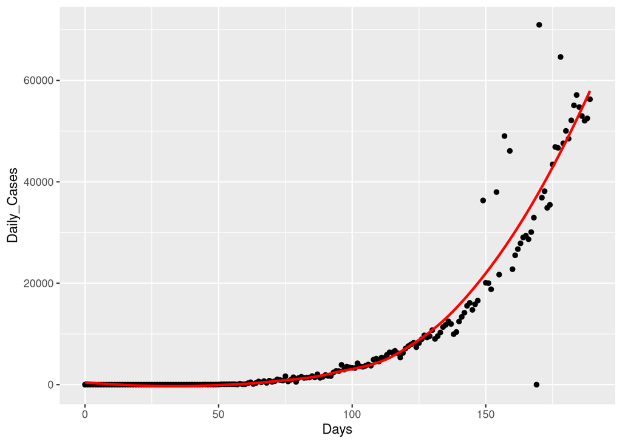

```r
loess1<-loess(Daily_Cases ~ Days, data = newCaseDate)


ggplot(newCaseDate, aes(x=Days, y=Daily_Cases))+
  geom_point()+
  geom_line(aes(y=predict(loess1)), color="red", size=1)
```

In the following code, we perform a grid search for the span to decide the appropriate amount of “wiggle” to give to the line.

Let’s do k-fold cross-validation to find the “best” span

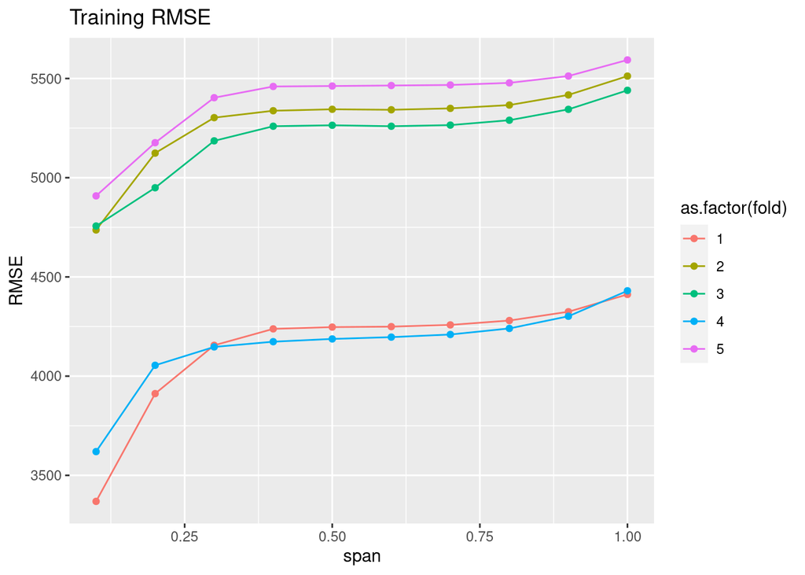

```r
set.seed(123)

### HOLD MANY FOLDS
kf<-5

### RANDOM SPLIT INTO K FOLDS
### RANDOM INDEXES
ind<-sample(1:186)

### CREATE DF
folds<-data.frame(ind,
                  fold=c(rep(1, 37), rep(2, 37),
                  rep(3, 37), rep(4, 37), rep(5, 38)))

### ADD ON COLUMNS TO ORIGINAL DAT
foldPoly<-newCaseDate[ind,]%>%
  cbind(folds)

### INITIALIZE RMSE DATAFRAME TO HOLD OUTPUT
RMSE <- data.frame('fold' = NA, 'span' = NA, 'RMSE' = NA, 'TestRMSE'=NA) # empty data frame to store RMSE

### LOOP FOR CROSS-VALIDATION
for(i in 1:kf){
  trainDat<-foldPoly%>%
    filter(fold!=i)

  testDat<-foldPoly%>%
    filter(fold==i)

#span
sp <- seq(0.1, 1, by=.1)

  for (j in 1:length(sp)){
    row<-length(sp)*(i-1)+j

    # build models
    model <- loess(Daily_Cases ~ Days, data = trainDat,
                 span=sp[j])

    # calculate RSME and store it for further usage
    RMSE[row,1] <-i
    RMSE[row,2] <- sp[j]
    RMSE[row,3] <- sqrt(sum((predict(model)-trainDat$Daily_Cases)^2)/length(trainDat$Daily_Cases)) # calculate RSME

   predTest<-predict(model, testDat)

  err<-predTest-testDat$Daily_Cases

  RMSE[row, 4]<-sqrt(sum(err^2, na.rm=TRUE)/(length(testDat$Daily_Cases)-sum(is.na(err))))

  }
}


ggplot(RMSE, aes(x=span, y=RMSE, color=as.factor(fold)))+
  geom_line()+
  geom_point()+
  ggtitle("Training RMSE")
```

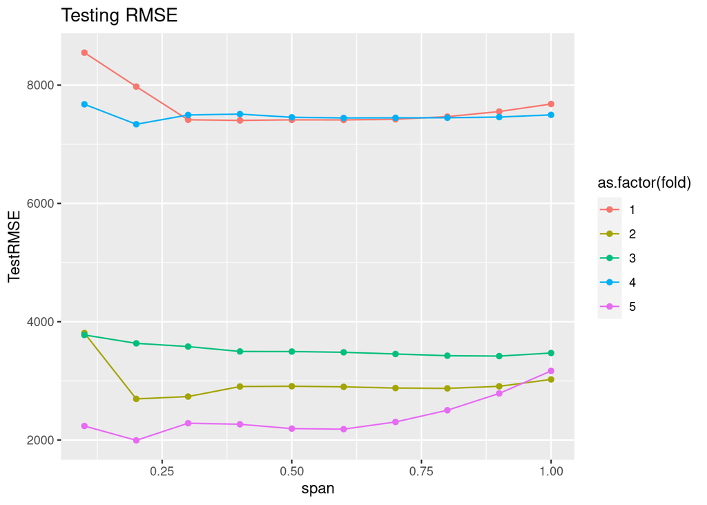

```r
ggplot(RMSE, aes(x=span, y=TestRMSE, color=as.factor(fold)))+
  geom_line()+
  geom_point()+
  ggtitle("Testing RMSE")
```

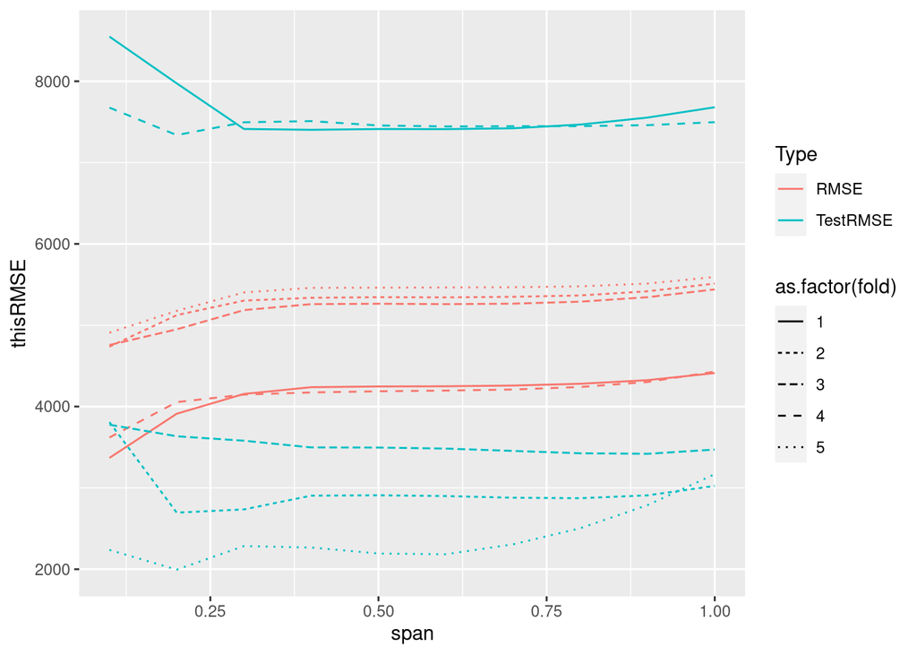

```r
### TIDY GRAPHICS TO PLOT TOGETHER
tidyRMSE<-RMSE%>%
  gather(key="Type", value="thisRMSE", -c(fold, span))


ggplot(tidyRMSE, aes(x=span, y=thisRMSE,
                     color=Type, lty=as.factor(fold)))+
  geom_line()
```

```r
### AGGREGATE CROSS_VALIDATION
cvRMSE<-RMSE%>%
  group_by(span)%>%
  summarise(avgTrainMSE=mean(RMSE),
            avgTestMSE=mean(TestRMSE),
            sdTrain=sd(RMSE),
            sdTest=sd(TestRMSE))

cvRMSE
```

```
## # A tibble: 10 × 5
##     span avgTrainMSE avgTestMSE sdTrain sdTest
##    <dbl>       <dbl>      <dbl>   <dbl>  <dbl>
##  1   0.1       4278.      5209.    724.  2742.
##  2   0.2       4643.      4727.    610.  2745.
##  3   0.3       4839.      4702.    632.  2556.
##  4   0.4       4894.      4716.    632.  2539.
##  5   0.5       4901.      4693.    629.  2544.
##  6   0.6       4902.      4685.    625.  2546.
##  7   0.7       4910.      4702.    622.  2528.
##  8   0.8       4931.      4744.    616.  2499.
##  9   0.9       4980.      4826.    612.  2459.
## 10   1         5078.      4968.    602.  2398.
```

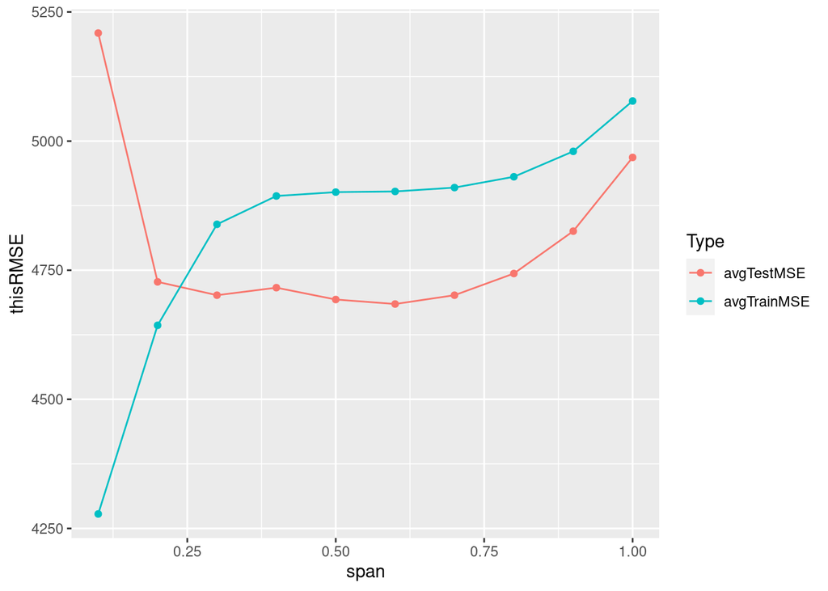

```r
cvRMSE%>%
  gather(key="Type", value=thisRMSE, -c(span))%>%
  filter(Type %in% c("avgTrainMSE", "avgTestMSE"))%>%
  ggplot(aes(x=span, y=thisRMSE, color=Type))+
  geom_line()+
  geom_point()
```

```r
### WHICH MINIMIZES
which.min(cvRMSE$avgTestMSE)
```

```
## [1] 6
```

```r
cvRMSE$avgTestMSE[which.min(cvRMSE$avgTestMSE)]
```

```
## [1] 4684.551
```

```r
## BEST SPAN
bestSpan<-cvRMSE$span[which.min(cvRMSE$avgTestMSE)]
bestSpan
```

```
## [1] 0.6
```

Using the chosen span, we fit the LOESS model:

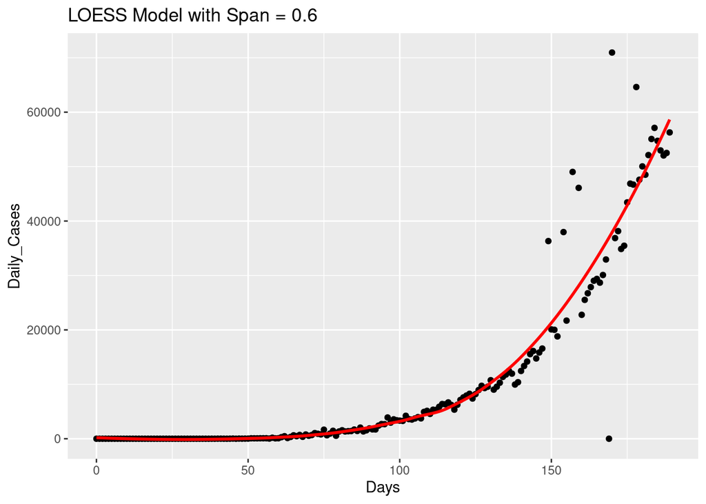

```r
loessB<-loess(Daily_Cases ~ Days, data = newCaseDate,
              span=bestSpan)


ggplot(newCaseDate, aes(x=Days, y=Daily_Cases))+
  geom_point()+
  geom_line(aes(y=predict(loessB)), color="red", size=1)+
  ggtitle(paste("LOESS Model with Span = ", bestSpan, sep=""))
```

### Ex 2: Synthetic

Repeat with the synthetic data.

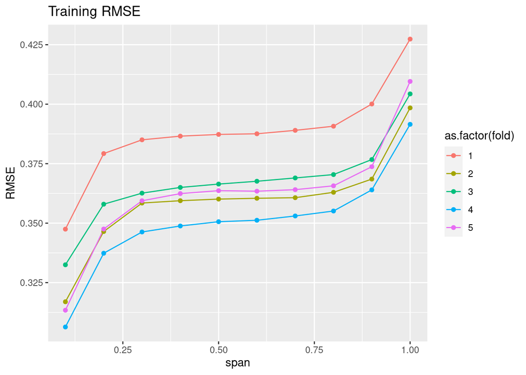

```r
set.seed(123)

### HOLD MANY FOLDS
kf<-5

### RANDOM SPLIT INTO K FOLDS
### RANDOM INDEXES
ind<-sample(1:150)

### CREATE DF
folds<-data.frame(ind,
                  fold=rep(1:kf, 150/kf))

### ADD ON COLUMNS TO ORIGINAL DAT
foldPoly<-poly.data[ind,]%>%
  cbind(folds)

### INITIALIZE RMSE DATAFRAME TO HOLD OUTPUT
RMSE <- data.frame('fold' = NA, 'span' = NA, 'RMSE' = NA, 'TestRMSE'=NA) # empty data frame to store RMSE

### LOOP FOR CROSS-VALIDATION
for(i in 1:kf){
  trainDat<-foldPoly%>%
    filter(fold!=i)

  testDat<-foldPoly%>%
    filter(fold==i)

#span
sp <- seq(0.1, 1, by=.1)

  for (j in 1:length(sp)){
    row<-length(sp)*(i-1)+j

    # build models
    model <- loess(y ~ x, data = trainDat,
                 span=sp[j])

    # calculate RSME and store it for further usage
    RMSE[row,1] <-i
    RMSE[row,2] <- sp[j]
    RMSE[row,3] <- sqrt(sum((predict(model)-trainDat$y)^2)/length(trainDat$y)) # calculate RSME

   predTest<-predict(model, testDat)

  err<-predTest-testDat$y

  RMSE[row, 4]<-sqrt(sum(err^2, na.rm=TRUE)/(length(testDat$y)-sum(is.na(err))))

  }
}


ggplot(RMSE, aes(x=span, y=RMSE, color=as.factor(fold)))+
  geom_line()+
  geom_point()+
  ggtitle("Training RMSE")
```

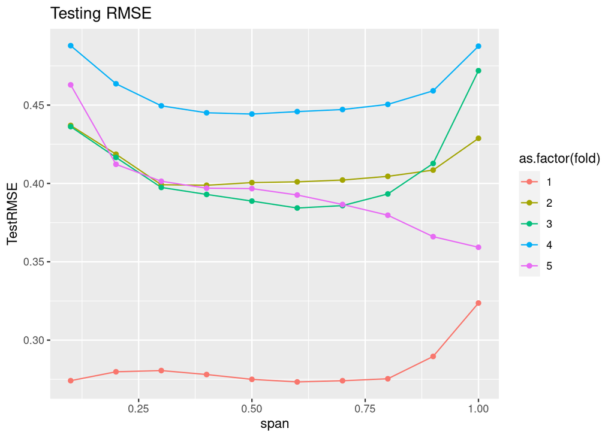

```r
ggplot(RMSE, aes(x=span, y=TestRMSE, color=as.factor(fold)))+
  geom_line()+
  geom_point()+
  ggtitle("Testing RMSE")
```

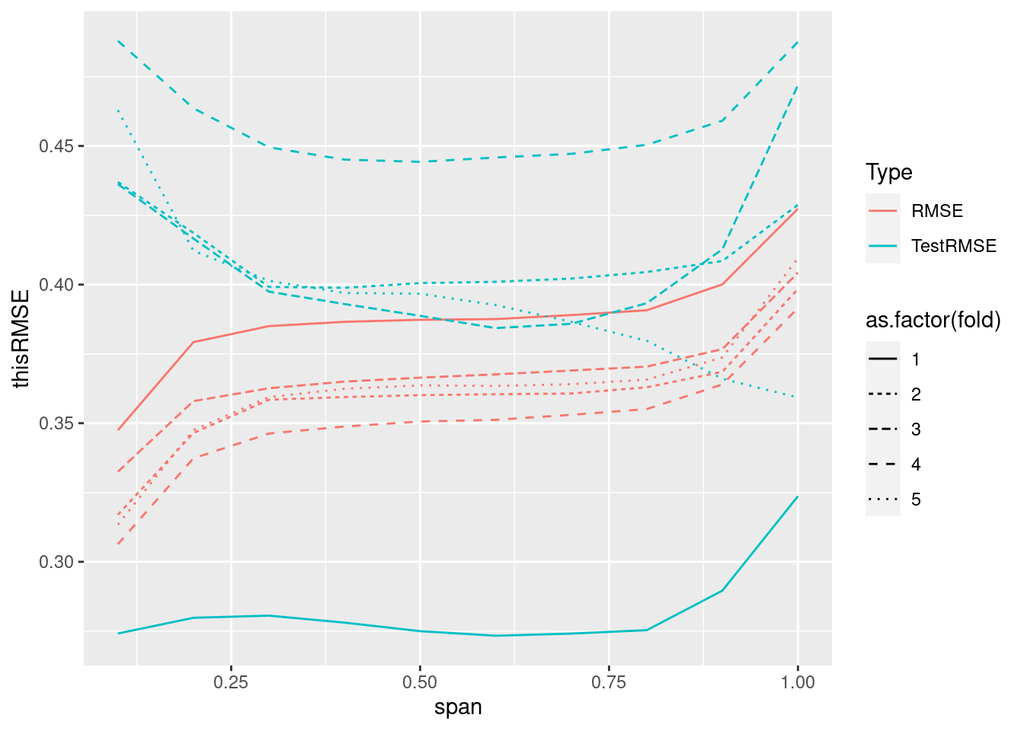

```r
### TIDY GRAPHICS TO PLOT TOGETHER
tidyRMSE<-RMSE%>%
  gather(key="Type", value="thisRMSE", -c(fold, span))


ggplot(tidyRMSE, aes(x=span, y=thisRMSE,
                     color=Type, lty=as.factor(fold)))+
  geom_line()
```

```r
### AGGREGATE CROSS_VALIDATION
cvRMSE<-RMSE%>%
  group_by(span)%>%
  summarise(avgTrainMSE=mean(RMSE),
            avgTestMSE=mean(TestRMSE),
            sdTrain=sd(RMSE),
            sdTest=sd(TestRMSE))

cvRMSE
```

```
## # A tibble: 10 × 5
##     span avgTrainMSE avgTestMSE sdTrain sdTest
##    <dbl>       <dbl>      <dbl>   <dbl>  <dbl>
##  1   0.1       0.323      0.420  0.0165 0.0841
##  2   0.2       0.354      0.398  0.0160 0.0694
##  3   0.3       0.362      0.386  0.0141 0.0626
##  4   0.4       0.364      0.382  0.0138 0.0621
##  5   0.5       0.366      0.381  0.0135 0.0631
##  6   0.6       0.366      0.379  0.0134 0.0639
##  7   0.7       0.367      0.379  0.0135 0.0638
##  8   0.8       0.369      0.381  0.0134 0.0646
##  9   0.9       0.377      0.387  0.0140 0.0637
## 10   1         0.406      0.414  0.0136 0.0710
```

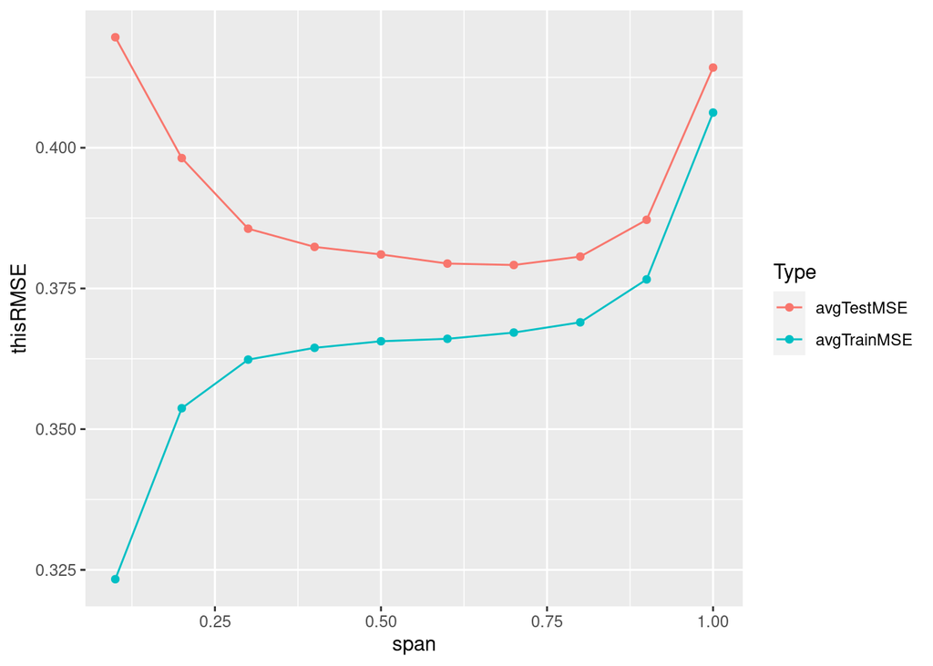

```r
cvRMSE%>%
  gather(key="Type", value=thisRMSE, -c(span))%>%
  filter(Type %in% c("avgTrainMSE", "avgTestMSE"))%>%
  ggplot(aes(x=span, y=thisRMSE, color=Type))+
  geom_line()+
  geom_point()
```

```r
### WHICH MINIMIZES
which.min(cvRMSE$avgTestMSE)
```

```
## [1] 7
```

```r
cvRMSE$avgTestMSE[which.min(cvRMSE$avgTestMSE)]
```

```
## [1] 0.3791673
```

```r
## BEST SPAN
bestSpan<-cvRMSE$span[which.min(cvRMSE$avgTestMSE)]
bestSpan
```

```
## [1] 0.7
```

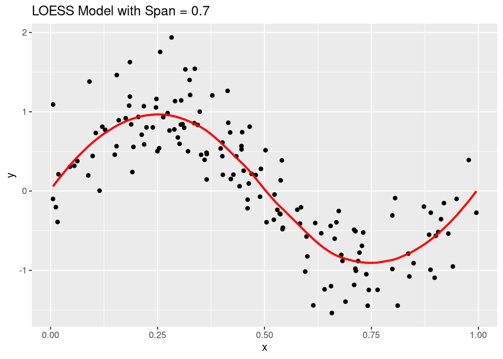

```r
## FINAL MOD
loessB2<-loess(y ~ x, data = poly.data,
              span=bestSpan)


ggplot(poly.data, aes(x=x, y=y))+
  geom_point()+
  geom_line(aes(y=predict(loessB2)), color="red", size=1)+
  ggtitle(paste("LOESS Model with Span = ", bestSpan, sep=""))
```

## 4. Compare the Models

### Ex 1. COVID-19

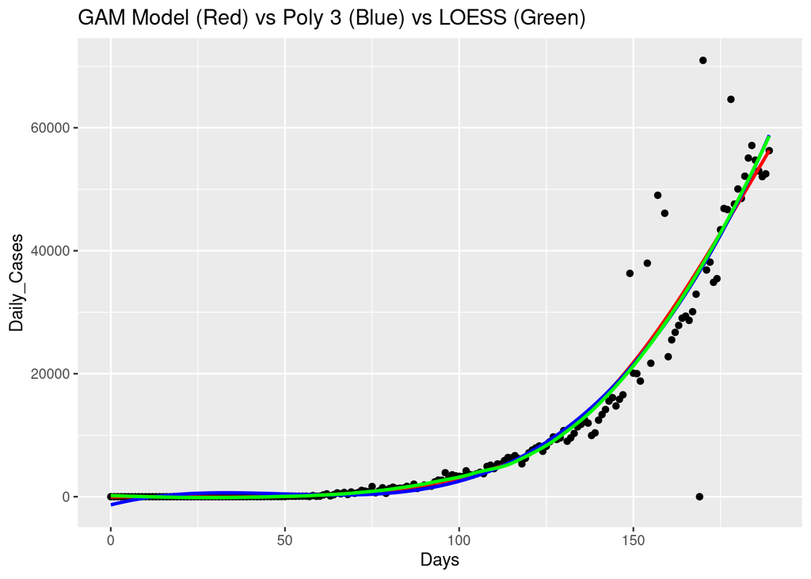

```r
ggplot(newCaseDate, aes(x=Days, y=Daily_Cases))+
  geom_point()+
  geom_line(aes(y=mod_gam$fitted.values), color="red", size=1)+
  geom_line(aes(y=model_3$fitted.values), color="blue", size=1)+
  geom_line(aes(y=predict(loessB)), color="green", size=1)+
  ggtitle("GAM Model (Red) vs Poly 3 (Blue) vs LOESS (Green)")
```

### Ex 2. Synthetic

```r
polyMod<-lm(y~poly(x, 10), data=poly.data)
#summary(polyMod)

polyMod5<-lm(y~poly(x, 5), data=poly.data)
```

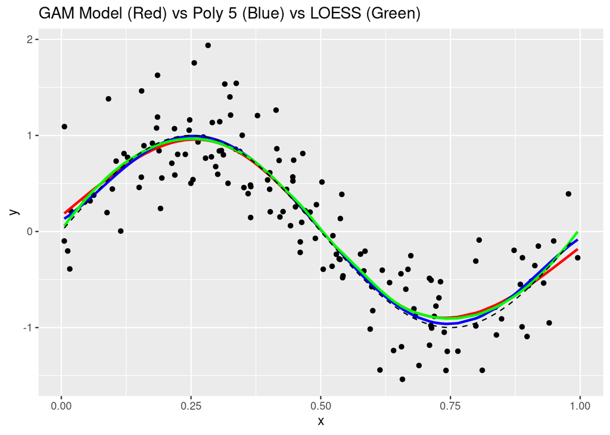

```r
vals <- seq(min(poly.data$x), max(poly.data$x), by = 0.01)

trueDF<-data.frame(vals)%>%
  mutate(y=sin(2*pi*vals))

ggplot(poly.data, aes(x=x, y=y))+
  geom_point()+
  geom_line(aes(y=mod_gam2$fitted.values), color="red", size=1)+
  geom_line(aes(y=polyMod5$fitted.values), color="blue", size=1)+
  geom_line(aes(y=predict(loessB2)), color="green", size=1)+
  geom_line(data=trueDF, aes(x=vals, y=y), lty=2)+
  ggtitle("GAM Model (Red) vs Poly 5 (Blue) vs LOESS (Green)")
```

So who is the winner? Drumroll please….

```r
polyMSE<-sum((predict(polyMod5, trueDF)-trueDF$y)^2)/length(trueDF$y)

gamMSE<-sum((predict(mod_gam2, trueDF)-trueDF$y)^2)/length(trueDF$y)

loessGAM<-sum((predict(loessB2, trueDF)-trueDF$y)^2)/length(trueDF$y)

polyMSE
```

```
## [1] 1.612422
```

```r
gamMSE
```

```
## [1] 1.567029
```

```r
loessGAM
```

```
## [1] 1.576906
```